# Homework 2

Ryann Liu (rl35976)

2025-01-19

# **Problem 1: Beauty, or not, in the Classroom**

The data for this analysis is based on a series of surveys on professors representing students at the University of Texas at Austin.

### **Part A**

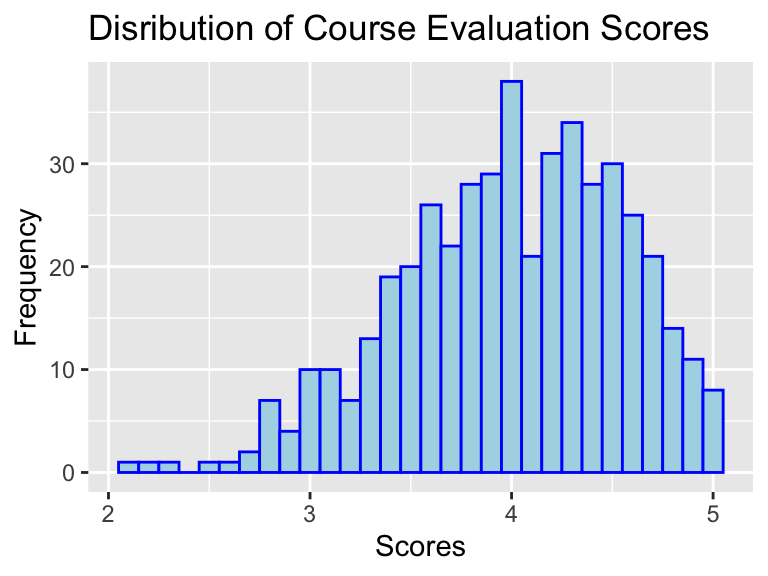

This graph is slightly skewed to the left, with a majority of professors receiving evaluation scores above 4. So, most students gave their professors relatively high scores.

### **Part B**

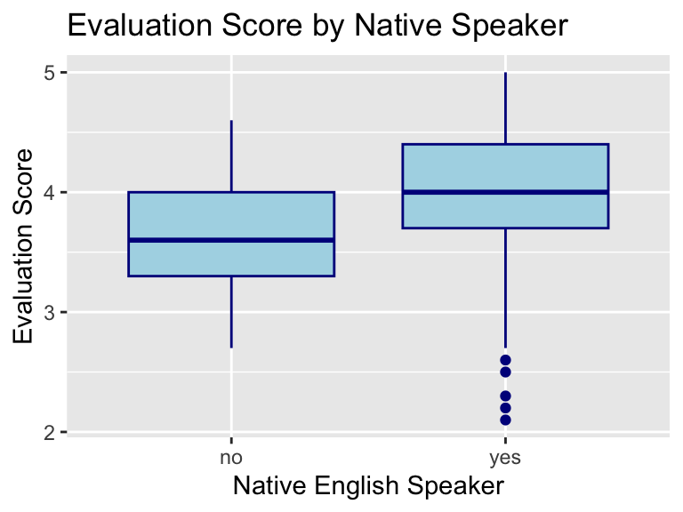

Above is the distribution of professors evaluation scores based on whether or not they are native English speakers. Overall, professors who are native English speakers had a higher median evaluation score, showing that native English-speaking professors generally were rated higher.

### **Part C**

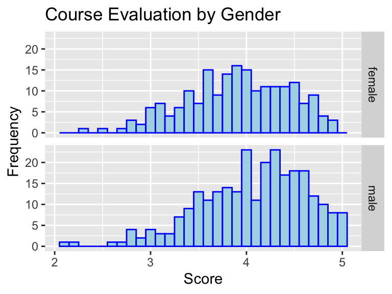

These graphs show the distribution of evaluation scores based on gender. Both graphs are left-skewed, however, male professors had generally more high scores than female professors.

### **Part D**

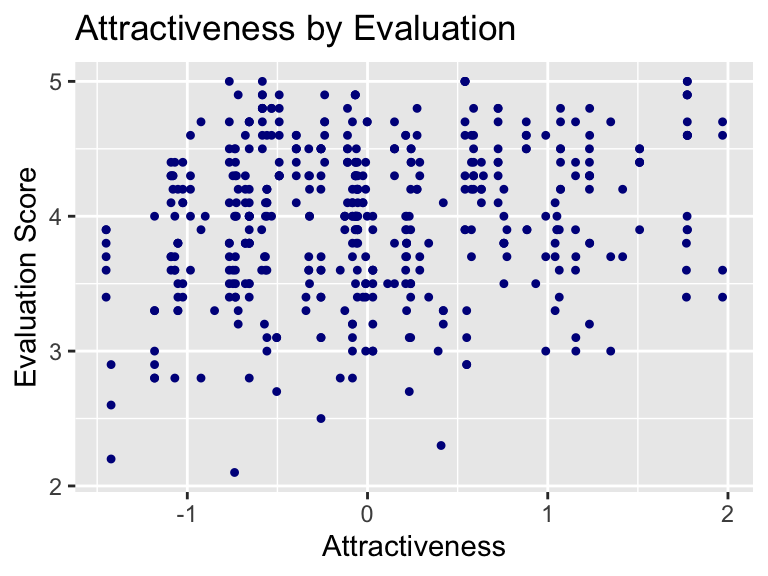

Above is a scatterplot displaying the relationship between professor’s attractiveness and their evaluation score. From the graph, we can see that there is not a strong correlation between the two variables, meaning that students didn’t base a professor’s evaluation score off of their physical attractiveness.

# **Problem 2: Bike Sharing**

The data from this analysis is from the Capital Bikeshare system’s historical log in Washington D.C.

### **Plot A**

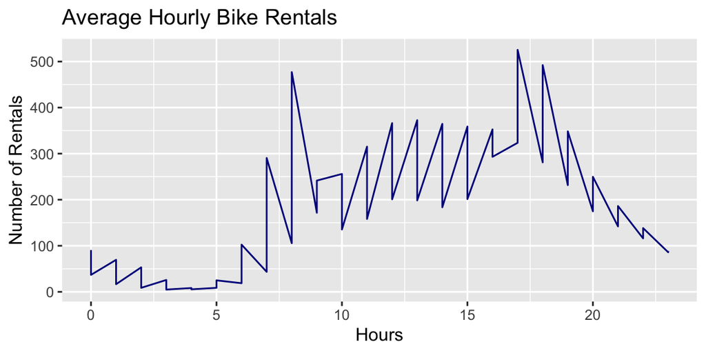

Above is a graph showing the average number of bike rentals by the hour of day. There are tall peaks around hour 8 and 17, with low rental rates around hour 4-5. From this we can tell when there were higher volumes of travelers.

### **Plot B**

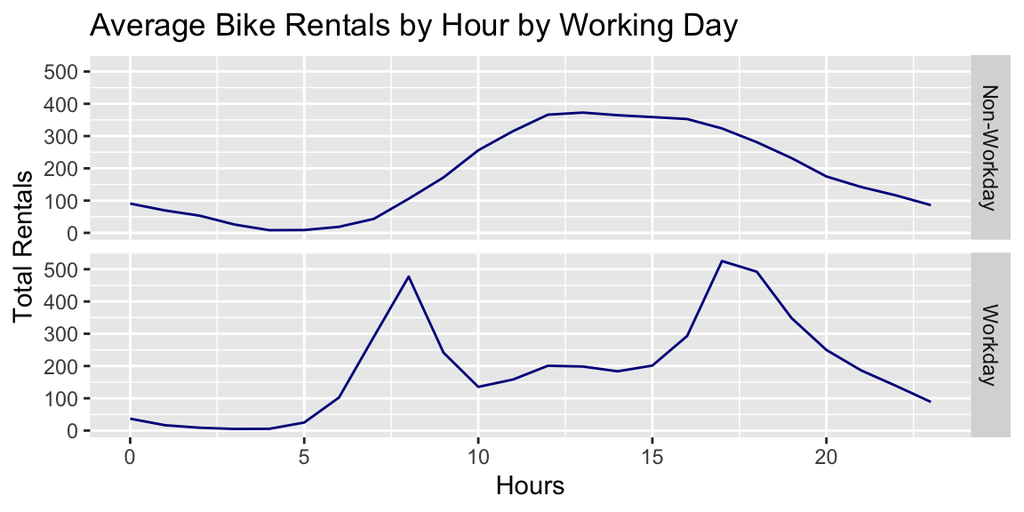

Above is two line graphs showing the average number of bike rentals per hour, separated by whether or not the day was a workday. On workdays, there were two peaks around hour 8 and hour 17, while there were no apparent peaks on non-workdays. There is also a trough during hours 10-15 on workdays. We can assume from this that work affects the amount of people traveling.

### **Plot C**

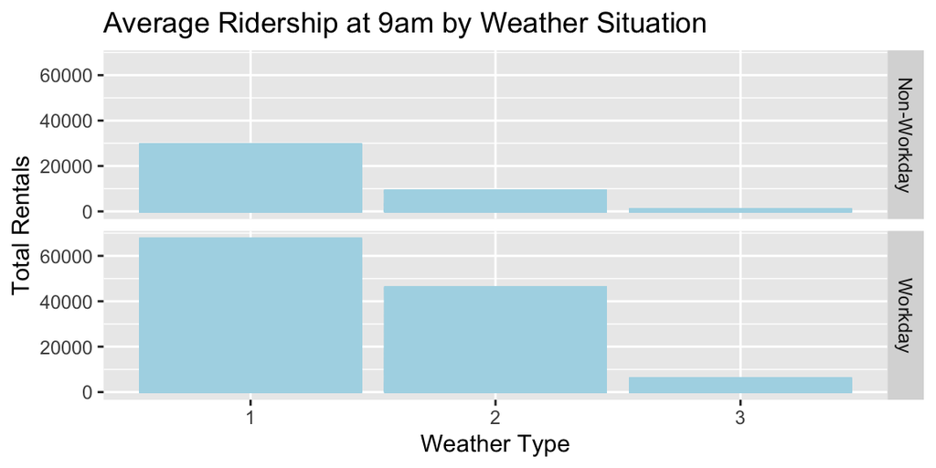

Above are two bar graphs displaying the total number of bike rentals based on the type of weather at 9am, separated by whether or not it was a workday. 1 represents clear weather, 2 represents misty/cloudy weather, and 3 represents light precipitation. There were no rentals on days with heavy precipitation (type 4). Overall, workdays with type 1 weather had the most rentals, and non-workdays with type 3 weather had the least. From this, we can interpret that there will be less ridership on weekends and on bad weather days.

# **Problem 3: Capital Metro UT Ridership**

The data for this analysis is from the Capital Metro bus network in Austin, TX, tracking ridership on buses near UT Austin.

### **Question 1**

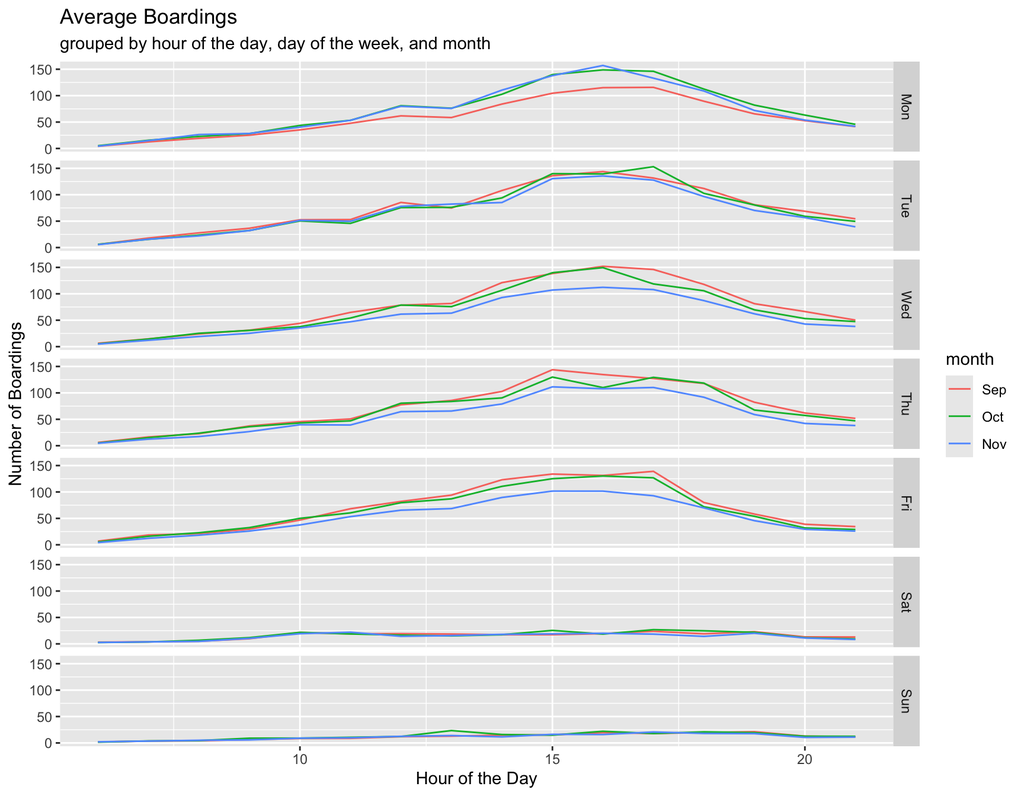

The line graphs above show the average number of boardings by hour, faceted by days of the week. There is also a different colored line representing each month (Sep., Oct., Nov.). As shown in the graphs, the peaks seem to change from day to day, with Saturdays and Sundays having lower peaks. The peaks across other days seem relatively similar, with Monday’s having slightly higher peaks. This may be due to the number of classes students have day-to-day, with students having no classes on weekends, thus resulting in the low number of boardings. Average boardings on Mondays in September may be lower because classes have not yet started during that time. Wed./Thu./Fri/ may be lower in November because of holidays as well as finals.

### **Question 2**

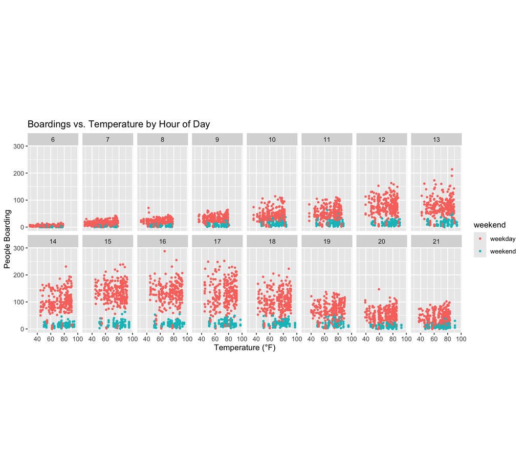

Above shows various scatterplots by the hour of day, showing the relationship between temperature and boardings. The plots are also colored based on whether or not it was a weekday. From the graphs, we can see that temperature does not have a noticeable affect on the number of people boarding the bus, as the plots are very sporadic throughout. However, we can see that ridership is affected by the hour of day, with higher numbers of riders during the hours 13-18. There is also a higher volume of riders on weekdays, as shown by colored plots.

# **Problem 4: Wrangling the Billboard Top 100**

The data from this analysis shows the weekly Billboard Top 100 charts from 1958-2021.

### **Part A**

Top 10 Most Popular Songs (from 1958-2021) based on the number of weeks on billboard

| performer | song | count |
| --- | --- | --- |
| Imagine Dragons | Radioactive | 87 |
| AWOLNATION | Sail | 79 |
| Jason Mraz | I’m Yours | 76 |
| The Weeknd | Blinding Lights | 76 |
| LeAnn Rimes | How Do I Live | 69 |
| LMFAO Featuring Lauren Bennett & GoonRock | Party Rock Anthem | 68 |
| OneRepublic | Counting Stars | 68 |
| Adele | Rolling In The Deep | 65 |
| Jewel | Foolish Games/You Were Meant For Me | 65 |
| Carrie Underwood | Before He Cheats | 64 |

Above is a table of the top 10 songs based on the number of weeks the song made it to the Billboard Top 100 list.

### **Part B**

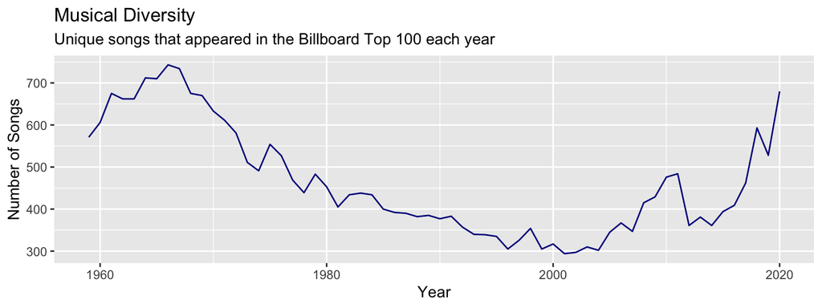

This line graph displays the number of unique songs that were in the Billboard Top 100 each year from 1959-2020, showing the musical diversity over the years. We can see that the number of unique songs seemed to decrease after 1968, and began to increase again after 2000. This could show that most popular songs after 1980 were older, and newer songs only got popular after the 2000’s.

### **Part C**

[figure not shown]

The plot above shows artists who had at least 30 songs that were considered a “ten-week hit”, meaning that the song appeared on the Billboard Top 100 for at least 10 weeks. Based on the plot, Elton John had the most popular songs, with over 50 “ten-week hits”.